# Cyclistic Bike-Share Analysis

Jusuf_Levnjak

03-20-2023

## Introduction

In this project I am going to perform exploratory analysis using the Data Analysis Phases i.e. Ask, Prepare, Process, Analyze, Share and Act on Cyclistic’s data obtained directly from company records available at *[Cyclistic trip data](https://divvy-tripdata.s3.amazonaws.com/index.html)* provided by *Motivate International Inc.* under this *[license](https://ride.divvybikes.com/data-license-agreement)*.

Cyclistic is a bike-share company which offers more than 5,800 different types of bicycles, hand tricycles, cargo bikes and over 600 docking stations. Their primary goal is growth, revenue and maximizing the number of annual memberships.

## Ask Questions and Insights

Lily Moreno the director of marketing is responsible for the development and her goal is to convert the casual riders into annual members so her main question is **“How do annual members and casual riders use Cyclistic bikes differently?”**

**Casual riders** — Customers who purchase single-ride or full-day passes.  
**Cyclistic members** — Customers who purchase annual memberships.

Before looking at the data I am going to ask and reply the following questions and insights about bike-share services:

**1. How do annaul members and casual riders use Cyclistic bikes differently?**  
1.1 Daily peek time.  
1.2 Weekly Number of Rides between Members and Casual riders.  
1.3 Average Ride Duration between Members and Casual riders.  
1.4 Monthly Number of Rides between Members and Casual riders.  
**2. Why would casual riders buy Cyclistic annaul memberships?**

## Prepare

Cyclistic is a fictional data that has been provided by the Google Data Analytics Professional Certificate course and with that assumption data is reliable, original, comprehensive, current, non-biased and was collected ethically.

After downloading the data from *March 2022* through *February 2023* and creating a copies of original files we can start to process the data.

## Process

Since the size of the given files and large datasets I will be using R/RStudio to manipulate the data: filter, clean, process, analyze and visualization.

The first step is to install and load packages like (tidyverse, lubridate, ggplot2) that we are going to use for manipulating the data in R.

### Cleaning and preparing the data

```r
install.packages(tidyverse)
install.packages(lubridate)
install.packages(ggplot2)

library(janitor)
library(tidyverse)
library(lubridate)
library(ggplot2)
library(scales)
```

After installing and loading packages, we need to set our data location where R can read the files from and it is always good practice to clean the R environment before loading new data.

```r
getwd()
setwd("C:/Users/jusuf/Desktop/Google Data Analyticsd Certificate/8. Data Analytics Capstone Project Complete a Case Study/12 months bikes of tripdata/CSV files")

rm(list=ls())

Mar_2022 <- read_csv("202203-divvy-tripdata.csv")
Apr_2022 <- read_csv("202204-divvy-tripdata.csv")
May_2022 <- read_csv("202205-divvy-tripdata.csv")
Jun_2022 <- read_csv("202206-divvy-tripdata.csv")
Jul_2022 <- read_csv("202207-divvy-tripdata.csv")
Aug_2022 <- read_csv("202208-divvy-tripdata.csv")
Sep_2022 <- read_csv("202209-divvy-tripdata.csv")
Oct_2022 <- read_csv("202210-divvy-tripdata.csv")
Nov_2022 <- read_csv("202211-divvy-tripdata.csv")
Dec_2022 <- read_csv("202212-divvy-tripdata.csv")
Jan_2023 <- read_csv("202301-divvy-tripdata.csv")
Feb_2023 <- read_csv("202302-divvy-tripdata.csv")
```

Once we loaded all of our files we need to combine all data sets into one for.

```r
bike_rides <- rbind(Mar_2022,Apr_2022,May_2022,Jun_2022,Jul_2022,Aug_2022,Sep_2022,Oct_2022,Nov_2022,Dec_2022,Jan_2023,Feb_2023)

View(bike_rides)
```

When all of our data is combine we can use str() function or View() to inspect our data and get known with it. While inspecting the data and going through it we can easily spot that we have some values missing in our data set.

And I am going to use the following code to remove missing data “NA” from our data set.

```r
bike_rides_clean <- na.omit(bike_rides)

-- Another way to clean the data is to use the following code
-- bike_rides_clean <- bike_rides %>% drop_na()

View(bike_rides_clean)
dim(bike_rides)
dim(bike_rides_clean)
str(bike_rides_clean)
```

If we check the number of rows using the dim() function we can see that after removing the empty cells we went down from 5,829,084 rows to 4,497,818.

After cleaning up the data, we need to make sure that all of the columns have the correct datatype and also add all the columns that we need for our analysis.  
In this case we have to convert “started_at” and “ended _at” from character to Date/Time type.

[figure not shown]

```r
bike_rides_clean <- bike_rides_clean %>% mutate(started_at = lubridate::mdy_hm(started_at),
                                                ended_at = lubridate::mdy_hm(ended_at))

str(bike_rides_clean)
```

[figure not shown]

Now we have to create few new columns such as “start_hour”, “Date”, “Month”, “Day”, “Year”, “Day_of_week”.  
And also modify “ride_length” column and convert it into to number so I can use it for further analysis.

```r
bike_rides_clean$start_hour <- lubridate::hour(bike_rides_clean$started_at)
bike_rides_clean$Date <- as.Date(bike_rides_clean$started_at)
bike_rides_clean$month <- format(as.Date(bike_rides_clean$Date), "%m")
bike_rides_clean$day <- format(as.Date(bike_rides_clean$Date), "%d")
bike_rides_clean$year <- format(as.Date(bike_rides_clean$Date), "%Y")
bike_rides_clean$day_of_week <- format(as.Date(bike_rides_clean$Date), "%A")

bike_rides_clean$ride_length <- difftime(bike_rides_clean$ended_at,bike_rides_clean$started_at)
bike_rides_clean$ride_length <- as.numeric(as.character(bike_rides_clean$ride_length))
```

The final step before analyzing the data I will make a quick check for any negative numbers in the trip duration and remove any rides that are less than 60 seconds (1 minute).

```r
bike_rides_clean_v2 <- bike_rides_clean[!(bike_rides_clean$ride_length < 60),]

View(bike_rides_clean_v2)
```

### Visualization

Once we cleaned the data and added all of the columns needed for our analysis we can proceed with visualizing the data to find out more about it.

**Count of Bike Rides by Hour**

First graph that I did is the number of Rides per hour to figure out at what time do people rent bikes the most.

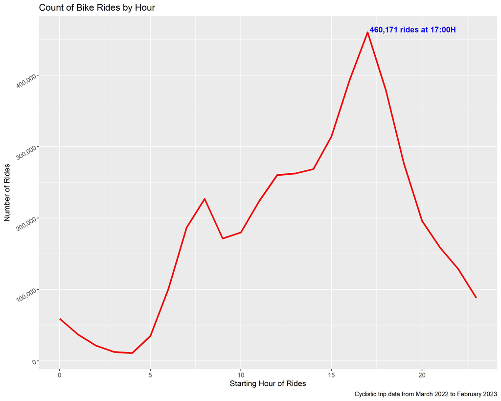

```r
bike_rides_clean_v2 %>% count(start_hour,sort = T)

bike_rides_clean_v2 %>% count(start_hour, sort = T) %>%
  ggplot() + geom_line(aes(x=start_hour, y=n),size=1.2, color="red") +
  scale_y_continuous(labels=comma) +
  labs(title="Count of Bike Rides by Hour",x="Starting Hour of Rides", y="Number of Rides",
       caption="Cyclistic trip data from March 2022 to February 2023") +
  annotate("text", x=17,y=460171,label=" 460,171 rides at 17:00H",hjust=0,vjust=0,color="blue",fontface="bold",size=4) +
  theme(axis.text.y=element_text(angle=30))

ggsave('Count_of_Bike_Rides_by_hour.jpg')

![](C:/Users/jusuf/Desktop/Google Data Analyticsd Certificate/8. Data Analytics Capstone Project Complete a Case Study/12 months bikes of tripdata/Pictures/Count_of_Bike_Rides_by_hour.jpg){#id .class width=70% height=70%}
```

At this graph we can see that the first peek of renting the bikes for both Casual and Member drivers is at 8AM and the second one is at 5PM. The reason for this is most likely because most of the drivers are using Bikes to commute from work to home and vice versa.

**Weekly Number of Rides between Members and Casual**

After that I wanted to figure out what days of the week are Members differing from Casual Riders. The following graph gave us a clear picture that Members are using Bikes almost twice more on weekdays compared to the casual drivers.

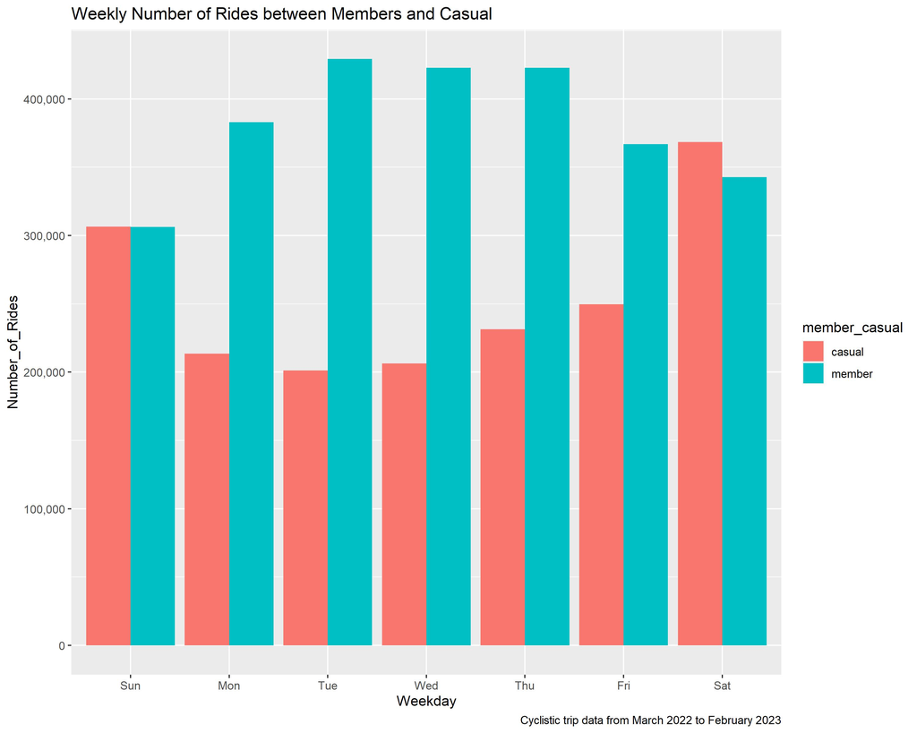

```r
bike_rides_clean_v2 %>%
  mutate(Weekday = wday(started_at, label = TRUE)) %>%
  group_by(member_casual, Weekday) %>%
  summarise(Number_of_Rides = n()
            ,Average_Ride_Duration = mean(ride_length)) %>%
  arrange(member_casual, Weekday)  %>%
  ggplot(aes(x = Weekday, y = Number_of_Rides, fill = member_casual)) +
  geom_col(position = "dodge") +
  scale_y_continuous(labels=comma) +
  labs(title="Weekly Number of Rides between Members and Casual",
       caption="Cyclistic trip data from March 2022 to February 2023")

ggsave('Weekly_Number_of_Rides_between_Members_and_Casual.jpg',
       width=10,
       height=8)

![](C:/Users/jusuf/Desktop/Google Data Analyticsd Certificate/8. Data Analytics Capstone Project Complete a Case Study/12 months bikes of tripdata/Pictures/Weekly_Number_of_Rides_between_Members_and_Casual.jpg){#id .class width=70% height=70%}
```

We can also see here that Casual riders are using bikes more on the weekend than Members.

**Average Ride Duration between Members and Casual**

On the following bar chart we can see that Casual riders (22 minutes in avg) are using bikes almost twice longer than Members (12 minutes in avg) which is matching with the fact that Member riders are using bikes for shorter relations work-home compared to the Casual riders.

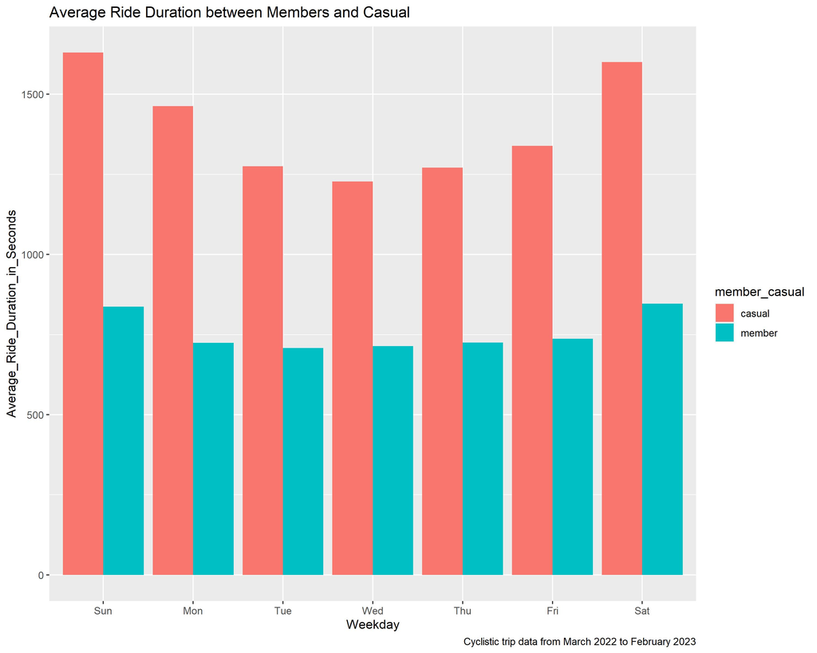

```r
bike_rides_clean_v2 %>%
  mutate(Weekday = wday(started_at, label = TRUE)) %>%
  group_by(member_casual, Weekday) %>%
  summarise(Number_of_Rides = n()
            ,Average_Ride_Duration_in_Seconds = mean(ride_length)) %>%
  arrange(member_casual, Weekday)  %>%
  ggplot(aes(x = Weekday,, y = Average_Ride_Duration_in_Seconds, fill = member_casual)) +
  geom_col(position = "dodge") +
  labs(title="Average Ride Duration between Members and Casual",
       caption="Cyclistic trip data from March 2022 to February 2023")

ggsave('Average_Ride_Duration_between_Members_and_Casual.jpg',
       width=10,
       height=8)

![](C:/Users/jusuf/Desktop/Google Data Analyticsd Certificate/8. Data Analytics Capstone Project Complete a Case Study/12 months bikes of tripdata/Pictures/Average_Ride_Duration_between_Members_and_Casual.jpg){#id .class width=70% height=70%}
```

**Monthly Number of Rides between Members and Casual**

On the Monthly number of rides between Members and Casual riders as we could except the busiest period of the year is Summer Jun through September and the very small amount of rides during the Winter November through February. Since the analyzed data is coming from Chicago area which can be very cold during the winter time with a lot of snow this is matching the expectations.

[figure not shown]

```r
bike_rides_clean_v2 %>%
  mutate(month = month(started_at, label = TRUE)) %>%
  group_by(member_casual, month) %>%
  summarise(Number_of_Rides = n()
            ,Average_Ride_Duration = mean(ride_length)) %>%
  arrange(member_casual, month)  %>%
  ggplot(aes(x = month, y = Number_of_Rides, fill = member_casual)) +
  geom_col(position = "dodge") +
  scale_y_continuous(labels=comma) +
  labs(title="Monthly Number of Rides between Members and Casual",x="Month",y="Number of Rides",
       caption="Cyclistic trip data from March 2022 to February 2023")

ggsave('Monthly_Number_of_Rides_between_Members_and_Casual.jpg',
       width=10,
       height=8)

![](C:/Users/jusuf/Desktop/Google Data Analyticsd Certificate/8. Data Analytics Capstone Project Complete a Case Study/12 months bikes of tripdata/Pictures/Monthly_Number_of_Rides_between_Members_and_Casual.jpg){#id .class width=70% height=70%}
```

**Top 10 Start Stations by Ride Count**

Last but not least I wanted to check what is the most popular and frequent Starting station. In this case *“Streeter dr & Grand ave”* has the most rides and after further investigation on this station I figured out that this street is around the *Chicago Children’s* Museum and *Ohio Street Beach* with very beautiful landscape for riders to enjoy their ride.

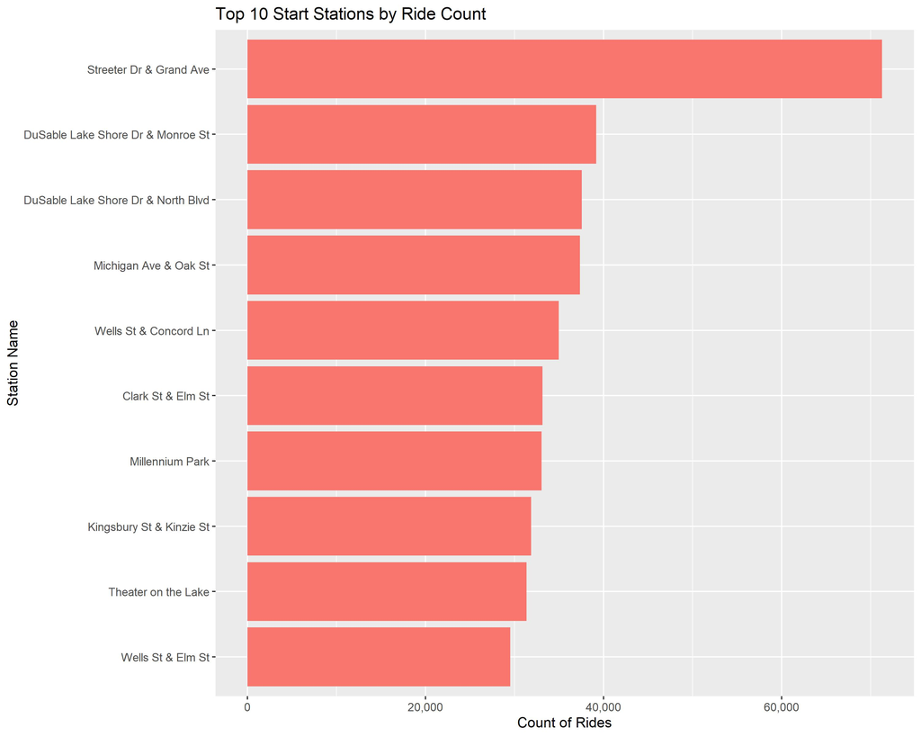

```r
bike_rides_clean_v2 %>% count(start_station_name,sort=TRUE) %>%
  top_n(10) %>% ggplot() +
  geom_col(aes(x=reorder(start_station_name,n), y=n,fill="red")) +
  coord_flip() + labs(title = "Top 10 Start Stations by Ride Count",
                      y = "Count of Rides", x="Station Name", fontface="bold") +
  scale_y_continuous(labels=comma) +
  theme(legend.position = "none")

ggsave('Top_10_Start_Stations_by_Ride_Count.jpg',
       width=10,
       height=8)

![](C:/Users/jusuf/Desktop/Google Data Analyticsd Certificate/8. Data Analytics Capstone Project Complete a Case Study/12 months bikes of tripdata/Pictures/Top_10_Start_Stations_by_Ride_Count.jpg){#id .class width=70% height=70%}
```

## Act

*Thank you for taking your time to read my case study project, hope you have enjoyed it!*